# BIOMI6300_Project1:OMV_Analysis

Jiucheng Ding

2023-02-23

#File setup:

```r
knitr::opts_chunk$set(echo = TRUE)
```

Although the production of OMVs have been well-reported and documented, the mechanism behind is still not quite clear; investigation on their formation mechanisms and bioactive roles is still required. This study tracked the growth and vesiculation values of the whole genome knockout library of Escherichia coli mutant strains through a high-throughput experimental method and systems-scale analysis. The mutations were reported to truncate the structure of the OMVs and led to hypervesiculation, and mutants in oxidative stress perform lowered level of vesiculation in E.coli.

#Install tidyverse without installation message:

```r
library(tidyverse)
```

#Loading data of OMV production values:

```r
vesiculation<- read_csv("../Data/vesiculation.csv")
```

#Perfrom some analysis with this OMV production data: #The data file shows the difference in OMV production of the gene-knockout library comparing to their normal state.

```r
summarize(vesiculation,
          averageLogOMV=mean(average.log.OMV),
          minimumLogOMV=min(average.log.OMV),
          maximumLogOMV=max(average.log.OMV),
          medianLogOMV=median(average.log.OMV),
          stdevLogOMV=sd(average.log.OMV),

          averageAntilogOMV=mean(average.antilog.omv),
          minimumAntilogOMV=min(average.antilog.omv),
          maximumAntilogOMV=max(average.antilog.omv),
          medianAntilogOMV=median(average.antilog.omv),
          averageSTDEVAntilog=mean(stdev.antilog))
```

```
## # A tibble: 1 × 10
##   averageLogOMV minim…¹ maxim…² median…³ stdev…⁴ avera…⁵ minim…⁶ maxim…⁷ media…⁸
##           <dbl>   <dbl>   <dbl>    <dbl>   <dbl>   <dbl>   <dbl>   <dbl>   <dbl>
## 1       -0.0255   -1.49    1.34 -0.00174   0.212    1.09  0.0351    24.2    1.02
## # … with 1 more variable: averageSTDEVAntilog <dbl>, and abbreviated variable
## #   names ¹minimumLogOMV, ²maximumLogOMV, ³medianLogOMV, ⁴stdevLogOMV,
## #   ⁵averageAntilogOMV, ⁶minimumAntilogOMV, ⁷maximumAntilogOMV,
## #   ⁸medianAntilogOMV
```

```r
#Standard Deviation of antilog:directly caluculated from the csv file, they have removed some outliers already.
```

#Then make scatterplot to show the distribution of OMV production change (Antilogged) for all samples, with a few outliers removed.

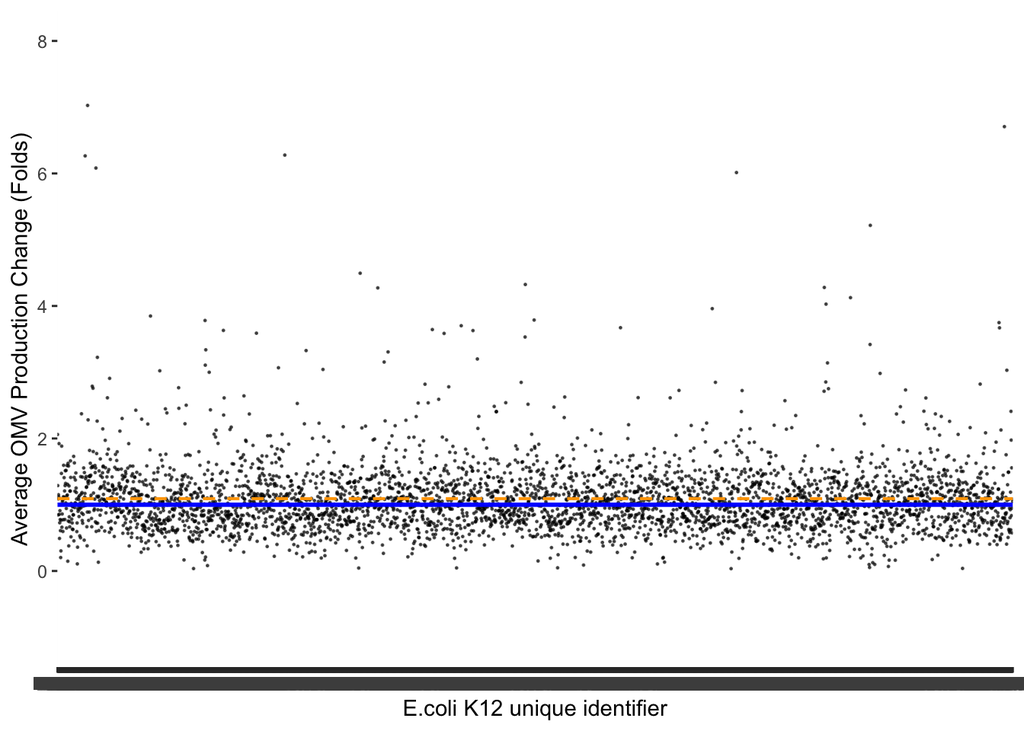

```r
ggplot(data=vesiculation) +
  aes(x=bID) +
  labs(x= "E.coli K12 unique identifier") +
  aes(y=average.antilog.omv) +
  ylim(-1,8)+
  labs(y="Average OMV Production Change (Folds)")+
  geom_point(size=0.20,alpha=0.6)+
  geom_hline(yintercept=1, color="blue", linetype="solid", size=1)+
  geom_hline(yintercept=1.091811, color="orange",linetype="dashed", size=0.7)
```

```r
  labs(title = "Average impact on OMV production (Antilogged, Linear)")
```

```
## $title
## [1] "Average impact on OMV production (Antilogged, Linear)"
##
## attr(,"class")
## [1] "labels"
```

Figure1: This scatterplot shows the OMV production change in antilog. Each dot represents an individual sample.A few outliers above 8 folds are ignored. The blue solid has a y-intercept of 1, indicating that the values above this line have an increased OMV production; those below represent those with lowered OMV production.

#Let’s make another figure with same data, but in log10 scale.

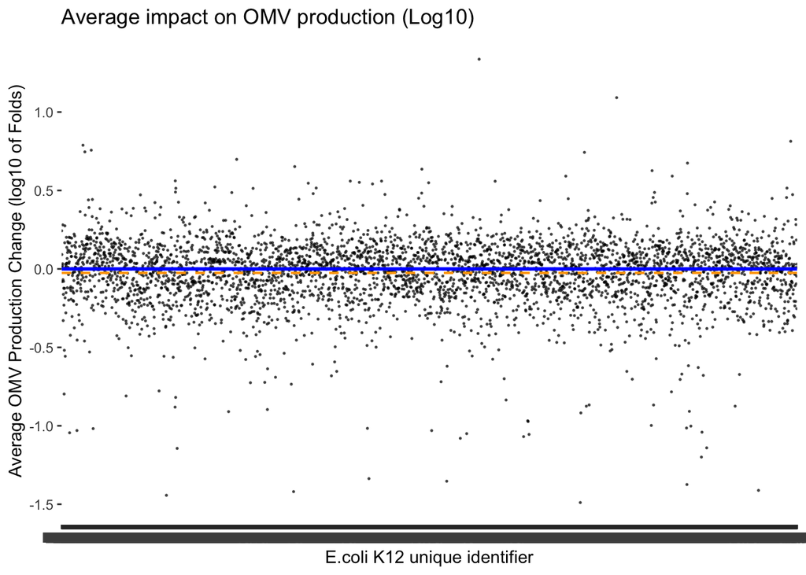

```r
ggplot(data=vesiculation) +
  aes(x=bID) +
  labs(x= "E.coli K12 unique identifier") +
  aes(y=average.log.OMV) +
  labs(y="Average OMV Production Change (log10 of Folds)")+
  geom_point(size=0.25, alpha=0.6)+
  geom_hline(yintercept=0, color="blue",linetype="solid", size=1)+
  geom_hline(yintercept=-0.02552768, color="orange",linetype="dashed", size=0.7)+
  labs(title = "Average impact on OMV production (Log10)")
```

Figure2: This scatterplot shows the OMV production change in log10. Each dot represents an individual sample.The blue solid line has a y-intercept of 0, indicating that the values above this line have an increased OMV production; those below represent those with lowered OMV production level. The orange dashed line indicates the mean value of change in OMV production, in log10.

#Make a histogram showing the frequency.

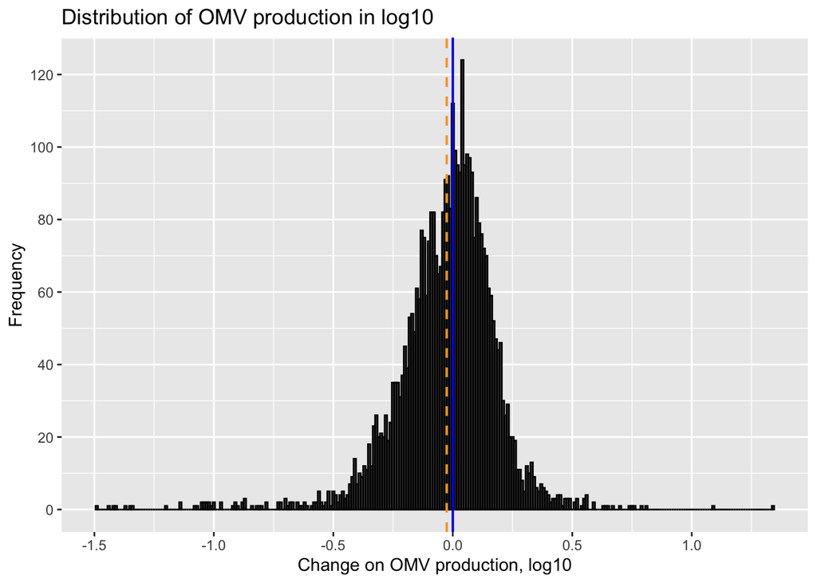

```r
ggplot(data=vesiculation) +
  aes(x=average.log.OMV) +
  labs(x="Change on OMV production, log10") +
  aes(y=..count..) +
  labs(y="Frequency") +
  scale_y_continuous(breaks = seq(0, 140, by = 20))+
  geom_histogram(color="black",binwidth=0.01) +
  geom_vline(xintercept=0, color="blue", size=0.7, linetype="solid") +
  geom_vline(xintercept=mean(vesiculation$average.log.OMV), color="orange", size=0.7, linetype="dashed") +
  labs(title="Distribution of OMV production in log10")
```

Figure3: Histogram for the distribution of change on OMV production relative to the normal state of E.coli. X-axis shows the changed value whereas Y-axis shows the frequency. The blue solid line shows when change on OMV production is 0, indicating the change at here equals 0. The orange dashed line shows the mean change in OMV production of all samples.

#Adding text discussion and conclusion:

Discussion and conclusion: According to figure 1 and 2, most of the dots are around the central line with not much change in OMV production. In figure 3, the distribution appears to be normally speard with mean value and the zero value very close to each other. However, this cannot lead to a conclusion that there is no effect on OMV production by gene-knocking out: there is a wide spectrum of genes knocked, it is obvious that the truncation on some of them lead to overvesiculation while others lead to decreased level. One of the explanation for the distribution is that the combination of all these genetic factors and mechanisms compromise with each other, and thus neutralize the overall average value close to the “no change” value. More information about the specfic genes subjected to treatment is required for a deeper understanding of the study.

```r
library(devtools)
```